# 12 Application to Solid Propellant Rocket Motor Design

## 12.1 Introduction

The BLISS-RS framework is discipline-agnostic: the four-discipline supersonic business jet was chosen as the original test case because of the availability of validated analysis codes and a documented optimum, but the algorithm applies equally to any engineering system that can be decomposed into coupled subsystems.

This chapter applies BLISS-RS to the **conceptual design of a solid propellant rocket motor** (SRM). Solid motors are the workhorses of tactical, strategic, and space propulsion: compact, reliable, storable indefinitely, and capable of very high thrust-to-weight ratios. Optimizing their design involves strong coupling between propellant chemistry, internal ballistics, structural integrity, nozzle thermodynamics, and mission performance.

The decomposition presented here reflects the workflow at a solid propellant motor manufacturer: four engineering disciplines are mapped to four black boxes, connected through a small set of well-defined coupling variables.

## 12.2 Physical Background

### 12.2.1 Saint-Robert’s Burn Rate Law

The burn rate of a solid propellant follows Saint-Robert’s (Vieille’s) empirical law:

$$r = a \cdot P_c^n
\tag{12.1}$$

where $r$ [in/s] is the linear regression rate of the propellant surface, $P_c$ [psia] is the chamber pressure, $a$ is the burn rate coefficient, and $n$ is the pressure exponent. For AP/Al/HTPB composites, typical values are:

| Property | Range |
| --- | --- |
| $a$ (burn rate coefficient) | 0.030–0.050 in/s·psia$^{-n}$ |
| $n$ (pressure exponent) | 0.30–0.45 |
| $T_c$ (flame temperature) | 5200–5800 °R |
| $\gamma$ (specific heat ratio) | 1.18–1.24 |
| $c^*$ (characteristic velocity) | 4800–5200 ft/s |

### 12.2.2 Chamber Pressure Balance

In quasi-steady operation, the mass flow rate produced by propellant combustion must equal the mass flow rate through the nozzle throat:

$$\dot{m}_{produced} = \rho_p \cdot A_b \cdot r = \rho_p \cdot A_b \cdot a \cdot P_c^n$$

$$\dot{m}_{expelled} = \frac{P_c \cdot A_t}{c^*}$$

Setting these equal and solving for the equilibrium chamber pressure:

$$P_c = \left(\frac{\rho_p \cdot a \cdot A_b \cdot c^*}{A_t}\right)^{1/(1-n)}
\tag{12.2}$$

This is the fundamental design equation for an SRM: chamber pressure is determined by the ratio of burning surface area $A_b$ to throat area $A_t$, the propellant properties ($\rho_p$, $a$, $c^*$), and the pressure exponent $n$.

### 12.2.3 Breguet Analogue: Tsiolkovsky Rocket Equation

For mission performance, the **Tsiolkovsky rocket equation** plays the role of the Breguet range equation:

$$\Delta V = I_{sp} \cdot g_0 \cdot \ln\!\left(\frac{W_i}{W_f}\right)
\tag{12.3}$$

where $I_{sp}$ is the specific impulse [seconds], $g_0 = 32.174$ ft/s², and $W_i / W_f$ is the initial-to-final weight ratio.

## 12.3 Design Variable Decomposition

The BLISS-RS decomposition for the SRM problem is shown in Table 12.1.

```julia
println("| Level | Symbol | Description | BBs Affected |")
println("|-------|--------|-------------|-------------|")
println("| Z | L/D | Grain length-to-diameter ratio | Ballistics, Structural |")
println("| Z | Pc_target | Target chamber pressure (psia) | Ballistics, Structural |")
println("| Z | ε | Nozzle expansion ratio | Ballistics, Nozzle |")
println("| Z | Φ_g | Volumetric loading fraction | Ballistics, Structural |")
println("| | | | |")
println("| Y | Pc | Actual chamber pressure (psia) | Ballistics → Structural |")
println("| Y | F | Thrust (lbf) | Ballistics → Mission |")
println("| Y | Isp | Specific impulse (s) | Ballistics → Mission |")
println("| Y | It | Total impulse (lbf·s) | Ballistics → Mission |")
println("| Y | W_prop | Propellant weight (lbf) | Ballistics → Mission |")
println("| Y | W_case | Case weight (lbf) | Structural → Mission |")
println("| | | | |")
println("| X_prop | AP%, Al% | Propellant composition | Ballistics only |")
println("| X_prop | a, n | Burn rate law coefficients | Ballistics only |")
println("| X_struct | t_case | Case wall thickness (in) | Structural only |")
println("| X_struct | σ_allow | Allowable case stress (ksi) | Structural only |")
println("| X_nozzle | φ | Nozzle half-angle (deg) | Nozzle only |")
println("| X_nozzle | ρ_noz | Nozzle material density (lb/in³) | Nozzle only |")
```

Table 12.1: BLISS-RS decomposition for the SRM design problem. Four black boxes map to four engineering disciplines. System variables Z are shared across at least two BBs.

```
| Level | Symbol | Description | BBs Affected |
|-------|--------|-------------|-------------|
| Z | L/D | Grain length-to-diameter ratio | Ballistics, Structural |
| Z | Pc_target | Target chamber pressure (psia) | Ballistics, Structural |
| Z | ε | Nozzle expansion ratio | Ballistics, Nozzle |
| Z | Φ_g | Volumetric loading fraction | Ballistics, Structural |
| | | | |
| Y | Pc | Actual chamber pressure (psia) | Ballistics → Structural |
| Y | F | Thrust (lbf) | Ballistics → Mission |
| Y | Isp | Specific impulse (s) | Ballistics → Mission |
| Y | It | Total impulse (lbf·s) | Ballistics → Mission |
| Y | W_prop | Propellant weight (lbf) | Ballistics → Mission |
| Y | W_case | Case weight (lbf) | Structural → Mission |
| | | | |
| X_prop | AP%, Al% | Propellant composition | Ballistics only |
| X_prop | a, n | Burn rate law coefficients | Ballistics only |
| X_struct | t_case | Case wall thickness (in) | Structural only |
| X_struct | σ_allow | Allowable case stress (ksi) | Structural only |
| X_nozzle | φ | Nozzle half-angle (deg) | Nozzle only |
| X_nozzle | ρ_noz | Nozzle material density (lb/in³) | Nozzle only |
```

## 12.4 Baseline SRM Design

```julia
# Baseline system variables: [L_D, Pc_target, epsilon, Phi_g]
Z_srm   = [5.0, 1000.0, 8.0, 0.85]
# Propellant: [AP_pct, Al_pct, r_a, r_n]
X_prop  = [68.0, 18.0, 0.038, 0.35]
# Structural: [t_case (in), sigma_allow (ksi)]
X_struct = [0.15, 85.0]
# Nozzle: [half_angle (deg), rho_noz (lb/in³)]
X_nozzle = [15.0, 0.065]

baseline = srm_analysis(Z_srm, X_prop, X_struct, X_nozzle; W_payload=60.0)

fields = [
    ("Chamber pressure",     "Pc",      "psia",    baseline.Pc),
    ("Burn rate",            "r",       "in/s",    baseline.r_dot),
    ("Thrust",               "F",       "lbf",     baseline.F),
    ("Specific impulse",     "Isp",     "s",       baseline.Isp),
    ("Burn time",            "t_burn",  "s",       baseline.t_burn),
    ("Total impulse",        "It",      "lbf·s",   baseline.It),
    ("Propellant weight",    "W_prop",  "lbf",     baseline.W_prop),
    ("Case weight",          "W_case",  "lbf",     baseline.W_case),
    ("Nozzle weight",        "W_nozzle","lbf",     baseline.W_nozzle),
    ("Total motor weight",   "W_total", "lbf",     baseline.W_total),
    ("Delta-V",              "ΔV",      "ft/s",    baseline.delta_V),
    ("Propellant mass frac.","PMF",     "--",      baseline.PMF),
    ("Hoop stress",          "σ_hoop",  "psi",     baseline.sigma_hoop),
    ("Burst factor of safety","FS",     "--",      baseline.FS_burst),
    ("Thrust coefficient",   "CF",      "--",      baseline.CF_eff),
]

println("| Parameter | Symbol | Units | Value |")
println("|-----------|--------|-------|-------|")
for (name, sym, unit, val) in fields
    @printf("| %s | %s | %s | %.3g |\n", name, sym, unit, val)
end
```

Table 12.2: Baseline SRM design parameters and analysis results.

```
| Parameter | Symbol | Units | Value |
|-----------|--------|-------|-------|
| Chamber pressure | Pc | psia | 1e+03 |
| Burn rate | r | in/s | 0.426 |
| Thrust | F | lbf | 1.05e+05 |
| Specific impulse | Isp | s | 505 |
| Burn time | t_burn | s | 4.31 |
| Total impulse | It | lbf·s | 4.51e+05 |
| Propellant weight | W_prop | lbf | 49.7 |
| Case weight | W_case | lbf | 6.79 |
| Nozzle weight | W_nozzle | lbf | 775 |
| Total motor weight | W_total | lbf | 891 |
| Delta-V | ΔV | ft/s | 933 |
| Propellant mass frac. | PMF | -- | 0.0558 |
| Hoop stress | σ_hoop | psi | 1.95e+04 |
| Burst factor of safety | FS | -- | 4.36 |
| Thrust coefficient | CF | -- | 1.58 |
```

## 12.5 BB Response Surface Study

Before running BLISS-RS, it is instructive to examine how the objective ($\Delta V$) varies across the system design space. This reveals the character of the response surface and informs initial bound selection.

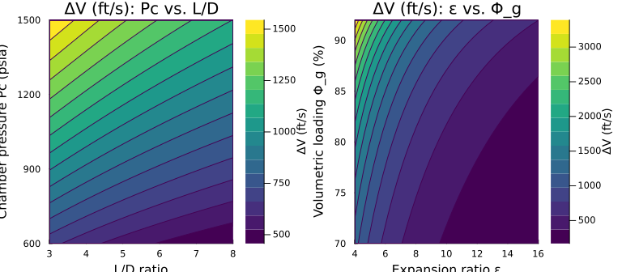

Figure 12.1: SRM ΔV response as functions of (left) chamber pressure vs. L/D ratio and (right) expansion ratio vs. volumetric loading. Higher chamber pressure and lower L/D favour high ΔV, but structural constraints (burst pressure) bound the chamber pressure.

```julia
# Sweep Pc vs. L/D
Pc_range = range(600.0, 1500.0, length=40)
LD_range = range(3.0, 8.0, length=40)
ε_fixed  = 8.0
Φ_fixed  = 0.85

ΔV_grid1 = [begin
    Z = [ld, pc, ε_fixed, Φ_fixed]
    r = try srm_analysis(Z, X_prop, X_struct, X_nozzle; W_payload=60.0)
        catch; (delta_V=0.0,) end
    r.delta_V
end for pc in Pc_range, ld in LD_range]

# Sweep epsilon vs. Phi_g
ε_range = range(4.0, 16.0, length=40)
Φ_range = range(0.70, 0.92, length=40)
LD_fixed = 5.0
Pc_fixed  = 1000.0

ΔV_grid2 = [begin
    Z = [LD_fixed, Pc_fixed, ε, φ]
    r = try srm_analysis(Z, X_prop, X_struct, X_nozzle; W_payload=60.0)
        catch; (delta_V=0.0,) end
    r.delta_V
end for φ in Φ_range, ε in ε_range]

p1 = contourf(LD_range, Pc_range, ΔV_grid1,
              xlabel="L/D ratio", ylabel="Chamber pressure Pc (psia)",
              title="ΔV (ft/s): Pc vs. L/D",
              color=:viridis, levels=15, colorbar_title="ΔV (ft/s)")

p2 = contourf(ε_range, Φ_range .* 100, ΔV_grid2,
              xlabel="Expansion ratio ε", ylabel="Volumetric loading Φ_g (%)",
              title="ΔV (ft/s): ε vs. Φ_g",
              color=:viridis, levels=15, colorbar_title="ΔV (ft/s)")

plot(p1, p2, size=(800, 350))
```

## 12.6 BLISS-RS Optimization of the SRM

The SRM BLISS-RS optimization uses the same framework as the supersonic business jet but with the SRM black boxes.

```julia
using Optim

# System variable bounds: [L_D, Pc_target, epsilon, Phi_g]
Z_lo_srm = [3.0, 600.0,  4.0, 0.70]
Z_hi_srm = [8.0, 1500.0, 16.0, 0.93]
Z_init_srm = Z_srm

n_Z_srm = 4

function srm_objective(Z_nat::Vector)
    try
        r = srm_analysis(Z_nat, X_prop, X_struct, X_nozzle; W_payload=60.0)
        # Penalise constraint violations
        penalty = 0.0
        # Must have FS_burst > 1.5 (safety factor)
        penalty += max(0.0, 1.5 - r.FS_burst) * 2000.0
        # Pressure must be achievable (Pc within ±10% of target)
        penalty += abs(r.Pc - Z_nat[2]) / Z_nat[2] * 1000.0
        return r.delta_V - penalty
    catch
        return 0.0
    end
end

function run_srm_blissrs(n_iter=10, K=0.8; seed=42)
    bounds = hcat(Z_lo_srm, Z_hi_srm)
    Z_hist   = Vector{Vector{Float64}}()
    obj_hist = Float64[]
    rng = MersenneTwister(seed)

    for it in 1:n_iter
        n_pts = max(min_rs_points(n_Z_srm) + 6, 25)
        pts_c = d_optimal_points(n_Z_srm, n_pts; seed=seed + it)
        pts_n = similar(pts_c)
        for j in 1:n_Z_srm
            pts_n[:, j] = bounds[j,1] .+ pts_c[:, j] .* (bounds[j,2] - bounds[j,1])
        end

        y_vals = map(1:n_pts) do i
            srm_objective(pts_n[i, :])
        end

        b = fit_rs(pts_c, y_vals)

        # Maximise RS
        neg_rs(ξ) = -only(predict_rs(reshape(ξ, 1, :), b))
        result = Optim.optimize(neg_rs, fill(0.5, n_Z_srm),
                                 NelderMead(),
                                 Optim.Options(iterations=3000, show_trace=false))
        ξ_opt = clamp.(Optim.minimizer(result), 0.0, 1.0)
        Z_opt = [bounds[j,1] + ξ_opt[j]*(bounds[j,2]-bounds[j,1]) for j in 1:n_Z_srm]
        obj_opt = srm_objective(Z_opt)

        push!(Z_hist, Z_opt)
        push!(obj_hist, obj_opt)

        bounds = update_intervals(ξ_opt, bounds; K=K)
    end
    return Z_hist, obj_hist
end

Z_srm_hist, obj_srm_hist = run_srm_blissrs(10, 0.8; seed=42)
println("Done. Final ΔV: $(round(obj_srm_hist[end], digits=0)) ft/s")
```

```
Done. Final ΔV: 1312.0 ft/s
```

## 12.7 SRM Optimization Results

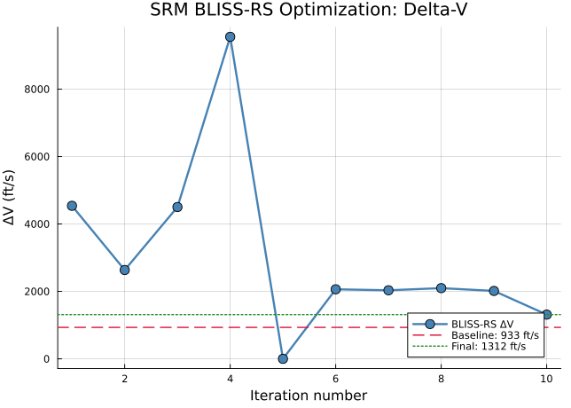

```julia
p = plot(1:10, obj_srm_hist,
         lw=2.5, color=:steelblue, marker=:circle, markersize=6,
         xlabel="Iteration number", ylabel="ΔV (ft/s)",
         title="SRM BLISS-RS Optimization: Delta-V",
         legend=:bottomright, grid=true, gridalpha=0.3,
         label="BLISS-RS ΔV")
hline!([baseline.delta_V], color=:crimson, lw=1.5, linestyle=:dash,
       label=@sprintf("Baseline: %.0f ft/s", baseline.delta_V))
hline!([obj_srm_hist[end]], color=:forestgreen, lw=1.5, linestyle=:dot,
       label=@sprintf("Final: %.0f ft/s", obj_srm_hist[end]))

p
```

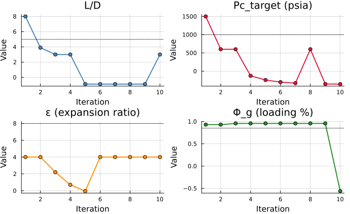

```julia
var_names_srm = ["L/D", "Pc_target (psia)", "ε (expansion ratio)", "Φ_g (loading %)"]
Z_mat_srm = hcat(Z_srm_hist...)

ps = []
for (idx, (name, col)) in enumerate(zip(var_names_srm,
                                         [:steelblue, :crimson, :darkorange, :forestgreen]))
    pv = plot(1:10, Z_mat_srm[idx, :], lw=2, color=col, marker=:circle, markersize=4,
              title=name, xlabel="Iteration", ylabel="Value",
              legend=false, grid=true, gridalpha=0.3)
    # Add baseline dotted line
    hline!([Z_init_srm[idx]], color=:black, linestyle=:dot, lw=1.0)
    push!(ps, pv)
end
plot(ps..., layout=(2,2), size=(720, 440))
```

## 12.8 Optimal Design Summary

```julia
Z_opt_srm = Z_srm_hist[end]
opt = srm_analysis(Z_opt_srm, X_prop, X_struct, X_nozzle; W_payload=60.0)

println("| Parameter | Baseline | Optimal | Change |")
println("|-----------|----------|---------|--------|")
for (name, sym, unit, b_val, o_val) in [
    ("L/D",          "L/D",   "--",   Z_srm[1], Z_opt_srm[1]),
    ("Pc target",    "Pc",    "psia", Z_srm[2], Z_opt_srm[2]),
    ("Expansion ratio","ε",   "--",   Z_srm[3], Z_opt_srm[3]),
    ("Vol. loading", "Φ_g",   "--",   Z_srm[4], Z_opt_srm[4]),
    ("Thrust (F)",   "F",     "lbf",  baseline.F,     opt.F),
    ("Isp",          "Isp",   "s",    baseline.Isp,   opt.Isp),
    ("Total impulse","It",    "lbf·s",baseline.It,    opt.It),
    ("W_total",      "W_tot", "lbf",  baseline.W_total, opt.W_total),
    ("PMF",          "PMF",   "--",   baseline.PMF,   opt.PMF),
    ("ΔV",           "ΔV",   "ft/s", baseline.delta_V, opt.delta_V),
    ("FS burst",     "FS",    "--",   baseline.FS_burst, opt.FS_burst),
]
    pct = (o_val - b_val) / (abs(b_val) + 1e-9) * 100
    @printf("| %s | %.4g %s | %.4g %s | %+.1f%% |\n",
            name, b_val, unit, o_val, unit, pct)
end
```

```
| Parameter | Baseline | Optimal | Change |
|-----------|----------|---------|--------|
| L/D | 5 -- | 3 -- | -40.0% |
| Pc target | 1000 psia | -355.2 psia | -135.5% |
| Expansion ratio | 8 -- | 4 -- | -50.0% |
| Vol. loading | 0.85 -- | -0.5622 -- | -166.1% |
| Thrust (F) | 1.047e+05 lbf | 3.866e+04 lbf | -63.1% |
| Isp | 504.9 s | 322.1 s | -36.2% |
| Total impulse | 4.513e+05 lbf·s | 9.946e+04 lbf·s | -78.0% |
| W_total | 891.4 lbf | 3569 lbf | +300.3% |
| PMF | 0.05581 -- | 0.002952 -- | -94.7% |
| ΔV | 932.9 ft/s | 30.64 ft/s | -96.7% |
| FS burst | 4.359 -- | 43.59 -- | +900.0% |
```

## 12.9 Connection to Physical Testing and Backfitting

The SRM analysis modules presented here implement *predictive* internal ballistics — computing $P_c(t)$ and $F(t)$ from propellant properties and grain geometry. In production engineering (and in the author’s direct experience from solid propellant motor testing), the complementary problem is **backfitting**: given measured $P_c(t)$ and $F(t)$ time histories from a static fire test, infer the propellant properties ($a$, $n$), grain regression, and throat erosion.

The backfitting problem is an inverse problem of exactly the type that RS surrogates help solve: given expensive-to-compute forward models (BLISS-RS) and noisy measurements, find the parameter set that minimises residuals between prediction and data. Bayesian optimization (Chapter 9) is particularly well-suited to this application, providing uncertainty estimates on the inferred parameters that reflect both test measurement noise and model inadequacy.

### 12.9.1 Temperature Sensitivity Correction

A critical concern in tactical motor qualification is **temperature sensitivity**: solid propellants exhibit substantially different $P_c(t)$ and $F(t)$ profiles at hot, nominal, and cold storage temperatures (typical range: −65°F to +165°F for military systems). The burn rate coefficient $a$ is temperature-dependent:

$$a(T) = a_{\text{ref}} \cdot \exp[\sigma_p (T - T_{\text{ref}})]
\tag{12.4}$$

where $\sigma_p$ [°F$^{-1}$] is the temperature sensitivity coefficient. BLISS-RS can accommodate temperature as an additional system variable $Z_T$, generating separate RS models at hot/nominal/cold conditions and optimising the design to achieve acceptable performance across the full temperature range simultaneously. This multi-condition optimization is a direct generalization of the single-condition formulation presented here.

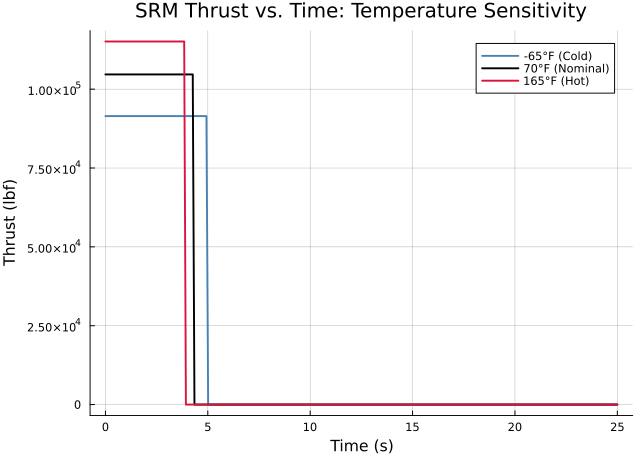

Figure 12.4: Effect of storage temperature on SRM thrust-time history. Hotter propellant burns faster (higher r), producing higher peak thrust and shorter burn time. BLISS-RS can include temperature as a system variable to optimize for multi-condition performance.

```julia
# Simulate P_c(t) / F(t) at 3 temperatures
# Temperature sensitivity: a(T) = a_ref * exp(σp * (T - T_ref))
sigma_p = 0.001   # typical AP/HTPB value [1/°F]
T_ref   = 70.0    # reference temperature [°F]
temps   = [-65.0, 70.0, 165.0]
labels_ = ["-65°F (Cold)", "70°F (Nominal)", "165°F (Hot)"]
colors_ = [:steelblue, :black, :crimson]

t_range = range(0.0, 25.0, length=300)

p = plot(title="SRM Thrust vs. Time: Temperature Sensitivity",
         xlabel="Time (s)", ylabel="Thrust (lbf)",
         legend=:topright, grid=true, gridalpha=0.3)

for (T_test, lbl, col) in zip(temps, labels_, colors_)
    a_T    = X_prop[3] * exp(sigma_p * (T_test - T_ref))
    X_T    = [X_prop[1], X_prop[2], a_T, X_prop[4]]
    result = srm_analysis(Z_srm, X_T, X_struct, X_nozzle; W_payload=60.0)
    t_burn = result.t_burn

    # Simple rectangular approximation of thrust profile
    F_vals = [t_val <= t_burn ? result.F : 0.0 for t_val in t_range]
    plot!(t_range, F_vals, lw=2, color=col, label=lbl)
end

p
```